# Multi-Reference Indicator Comparison: Doctor Visits: Smoothed Adj CLI

Author

Delphi Group

Published

August 18, 2026

This report evaluates one **candidate indicator** against multiple **reference indicators**. Each diagnostic is computed pairwise; references are not combined.

| Role | Source | Indicator | Label |
| --- | --- | --- | --- |
| Candidate | doctor-visits | smoothed_adj_cli | Doctor Visits: Smoothed Adj CLI |
| Reference | quidel | covid_ag_smoothed_pct_positive | Quidel: Smoothed % Positive COVID Antigen |
| Reference | hospital-admissions | smoothed_covid19_from_claims | Hospital Admissions: Smoothed COVID-19 from Claims |
| Reference | chng | 7dav_inpatient_covid | CHNG: 7-day Avg Inpatient COVID |
| Reference | chng | 7dav_outpatient_covid | CHNG: 7-day Avg Outpatient COVID |

## 1 Exploratory Data Analysis

This section checks overlap, scale, missingness, and variation for each candidate/reference pair.

### 1.1 Data Sources and Pairwise Overlap

The candidate and references are loaded once, then paired by panel and time. A panel is one location plus any configured extra key columns. Dashed vertical lines mark the requested analysis window; overlap values are pairwise with the candidate.

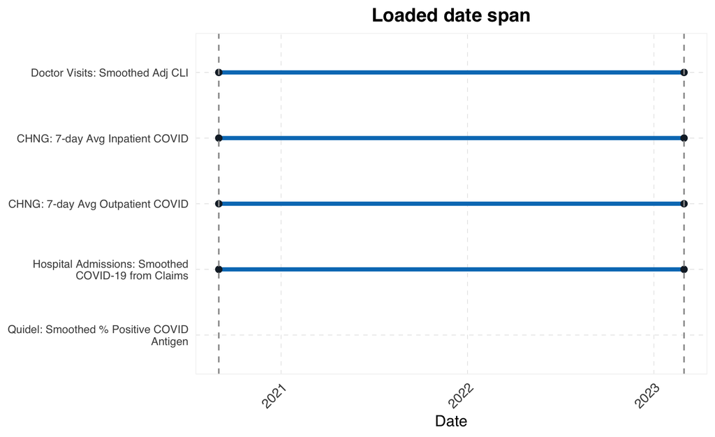

Loaded data volume and candidate/reference overlap.

| Role | Indicator | Rows loaded | Panels loaded | Locations loaded | Dates loaded | First date | Last date | Overlap rows | Overlap locations | Overlap dates | Overlap percent |
| --- | --- | --- | --- | --- | --- | --- | --- | --- | --- | --- | --- |
| Candidate | Doctor Visits: Smoothed Adj CLI | 47,668 | 53 | 53 | 912 | 2020-09-01 | 2023-03-01 | Not applicable | Not applicable | Not applicable | Not applicable |
| Reference | CHNG: 7-day Avg Inpatient COVID | 51,867 | 58 | 58 | 912 | 2020-09-01 | 2023-03-01 | 46,935 | 53 | 912 | 88.7% |
| Reference | CHNG: 7-day Avg Outpatient COVID | 51,072 | 56 | 56 | 912 | 2020-09-01 | 2023-03-01 | 47,117 | 53 | 912 | 92.3% |
| Reference | Hospital Admissions: Smoothed COVID-19 from Claims | 45,004 | 51 | 51 | 912 | 2020-09-01 | 2023-03-01 | 45,004 | 51 | 912 | 93.1% |
| Reference | Quidel: Smoothed % Positive COVID Antigen | 0 | 0 | 0 | 0 | NA | NA | 0 | 0 | 0 | 0.0% |

### 1.2 Time Series Overview

Each indicator is standardized within panel; the plot shows the median standardized value across panels at each date. A panel is one location plus any configured extra key columns. This overview uses the loaded data for each indicator and is not recomputed separately for each candidate/reference pair.

For each indicator and location, values are standardized as

$$Z_{g,t}=\frac{X_{g,t}-\bar{X}_g}{s_g},$$

where $X_{g,t}$ is the raw value, $\bar{X}_g$ is the panel mean, and $s_g$ is the panel standard deviation.

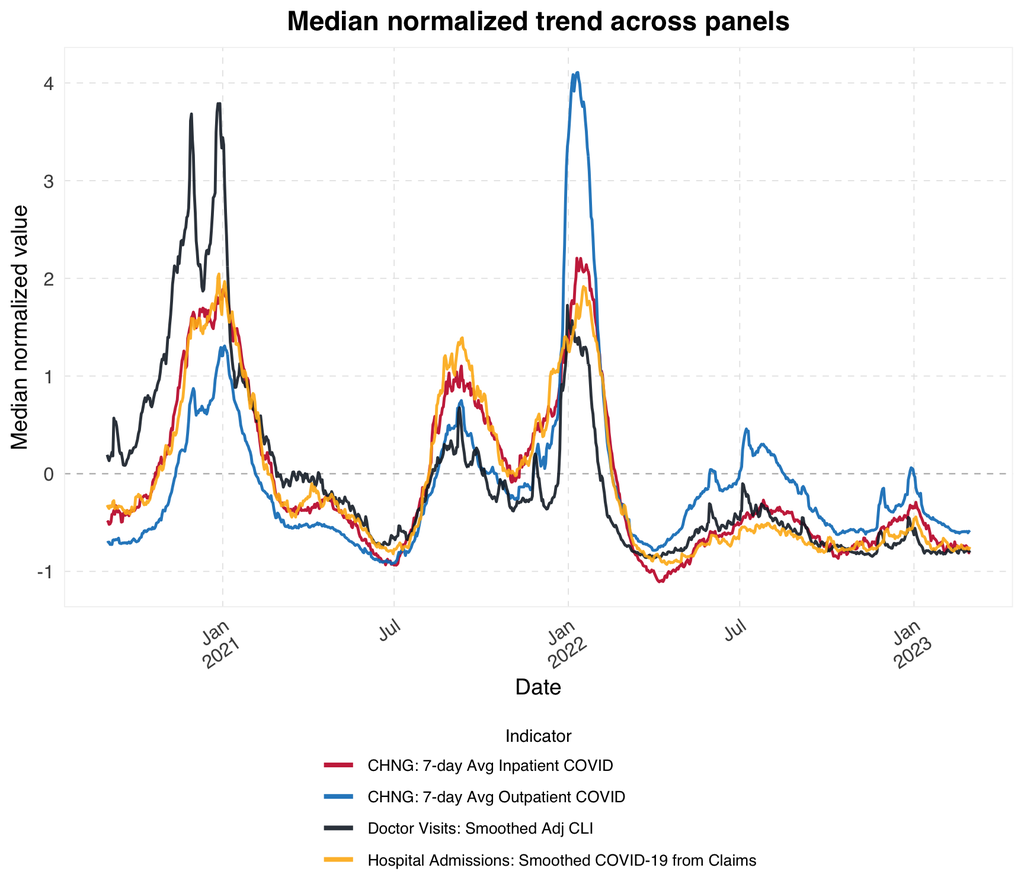

### 1.3 Quantile Trends

This plot shows cross-panel quantiles after within-panel standardization. A panel is one location plus any configured extra key columns. Candidate quantiles are recomputed on each candidate/reference overlap.

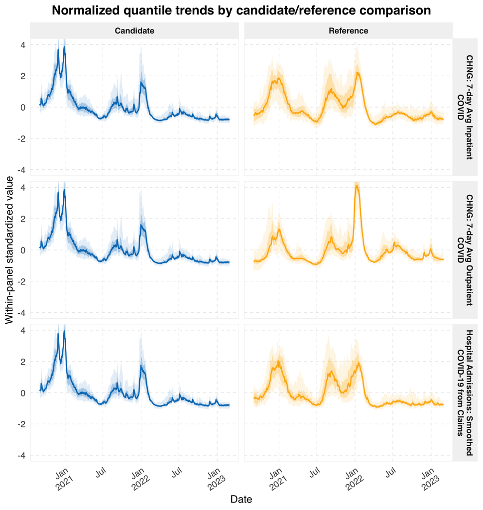

### 1.4 Coverage and Missingness

This plot shows candidate, reference, and pairwise-overlap location counts by date. “Both” is the sample size for date-specific spatial correlations.

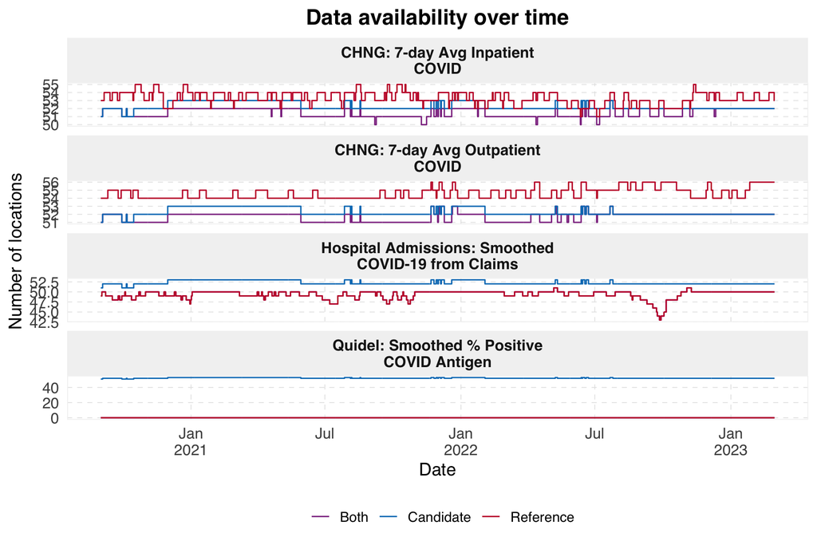

### 1.5 Summary Statistics and Missingness

This section summarizes values and missingness by panel. A panel is one location plus any configured extra key columns. Because Epidata sources usually omit unavailable rows rather than returning explicit missing values, missingness is computed after expanding each candidate/reference pair to the union of candidate and reference panels over the requested time grid.

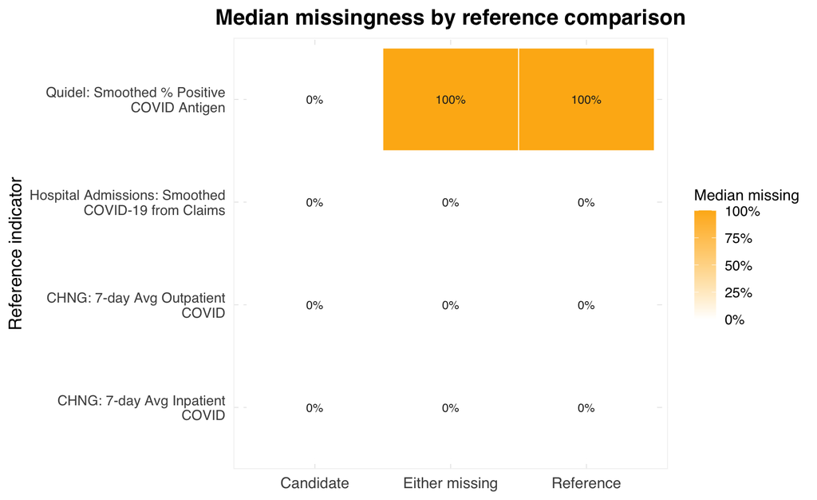

| Reference | Geo value | Geo name | Periods | Candidate mean | Candidate missing | Reference mean | Reference missing | Either missing |
| --- | --- | --- | --- | --- | --- | --- | --- | --- |
| CHNG: 7-day Avg Inpatient COVID | as | American Samoa | 912 |  | 100.0% | 0.04872389791183307 | 52.7% | 100.0% |
| CHNG: 7-day Avg Inpatient COVID | fm | fm | 912 |  | 100.0% | 0 | 91.4% | 100.0% |
| CHNG: 7-day Avg Inpatient COVID | gu | Guam | 912 |  | 100.0% | 0 | 94.2% | 100.0% |
| CHNG: 7-day Avg Inpatient COVID | mh | mh | 912 |  | 100.0% | 0 | 99.2% | 100.0% |
| CHNG: 7-day Avg Inpatient COVID | mp | Northern Mariana Islands | 912 |  | 100.0% | 0 | 43.4% | 100.0% |
| CHNG: 7-day Avg Outpatient COVID | as | American Samoa | 912 |  | 100.0% | 0.003082175609041972 | 6.6% | 100.0% |
| CHNG: 7-day Avg Outpatient COVID | gu | Guam | 912 |  | 100.0% | 0.0140887659303573 | 60.0% | 100.0% |
| CHNG: 7-day Avg Outpatient COVID | mp | Northern Mariana Islands | 912 |  | 100.0% | 0.007599184473303418 | 9.0% | 100.0% |
| Hospital Admissions: Smoothed COVID-19 from Claims | pr | Puerto Rico Commonwealth | 912 | 33.21232647750865 | 68.3% |  | 100.0% | 100.0% |
| Hospital Admissions: Smoothed COVID-19 from Claims | vi | U.S. Virgin Islands | 912 | 4.868610596309112 | 4.9% |  | 100.0% | 100.0% |

[output cut: 210 more lines]

### 1.6 Noise Assessment

Coefficient of variation (CV) is `sd(value) / abs(mean(value))` within location. Negative CV difference, or points below the diagonal, means the candidate has lower relative variation than the reference.

| reference_name | Locations compared | Median candidate CV | Median reference CV | Median CV difference | % candidate smoother |
| --- | --- | --- | --- | --- | --- |
| CHNG: 7-day Avg Inpatient COVID | 52 | 0.9508185097919908 | 0.7137924664802933 | 0.2254910608537457 | 5.769230769230769 |
| CHNG: 7-day Avg Outpatient COVID | 53 | 0.9516667331445091 | 0.7399402064368154 | 0.2510710399839838 | 16.9811320754717 |
| Hospital Admissions: Smoothed COVID-19 from Claims | 51 | 0.9443584205126945 | 0.9322892522535864 | 0.005394875916956643 | 47.05882352941176 |
| Quidel: Smoothed % Positive COVID Antigen | 0 |  |  |  |  |

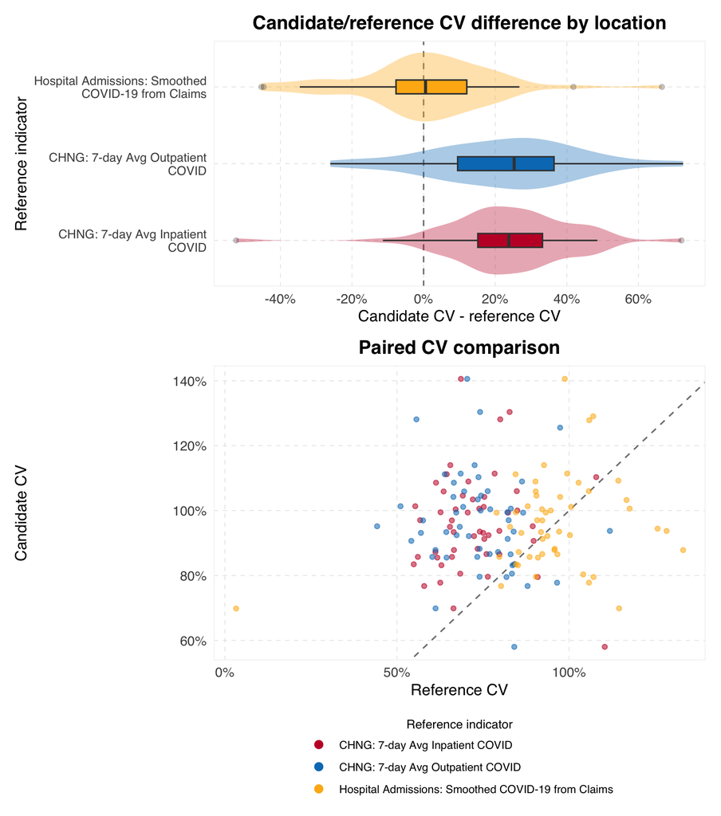

## 2 Correlation Analysis

### 2.1 Correlation Over Locations

Let $C_{g,t}$ be the candidate value and $R^{(k)}_{g,t}$ be reference $k$ at location $g$ and time $t$. $\operatorname{cor}_S(x,y)$ is Spearman correlation after dropping missing pairs.

For each reference indicator $k$ and date $t$, the pairwise spatial correlation is computed across locations:

$$s^{(k)}_{\text{space},t}
= \operatorname{cor}_S
\left(
\{C_{g,t}\}_{g},
\{R^{(k)}_{g,t}\}_{g}
\right).$$

Faint lines are date-specific correlations; thick lines are LOESS trends.

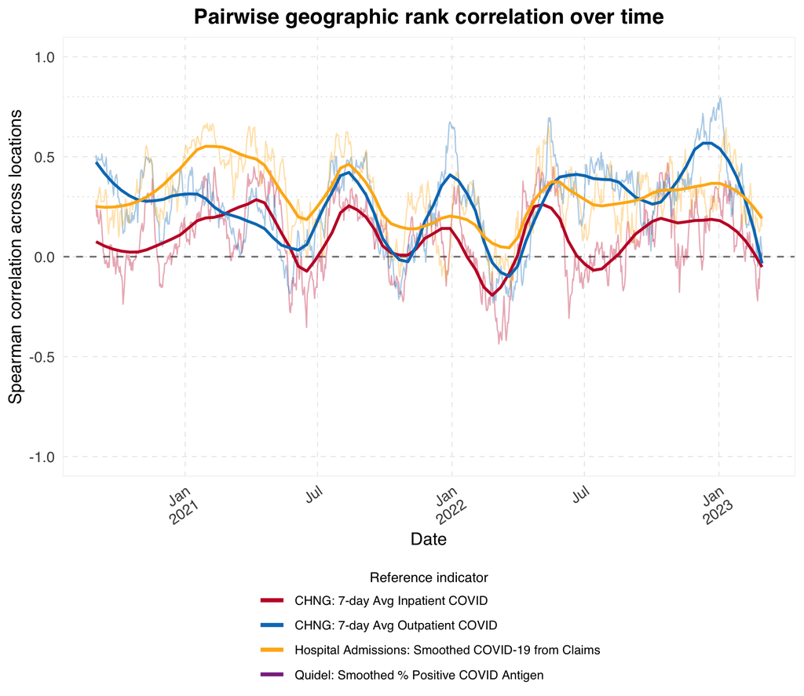

#### 2.1.1 Dates With Minimum Spatial Agreement

Dates with minimum spatial correlation for each candidate/reference pair.

Dates with minimum spatial agreement for each candidate/reference pair.

| Reference | Date | Locations compared | Spatial Spearman correlation |
| --- | --- | --- | --- |
| CHNG: 7-day Avg Inpatient COVID | 2022-03-06 | 51 | -0.437 |
| CHNG: 7-day Avg Inpatient COVID | 2022-03-16 | 51 | -0.419 |
| CHNG: 7-day Avg Inpatient COVID | 2022-03-10 | 51 | -0.418 |
| CHNG: 7-day Avg Inpatient COVID | 2022-03-09 | 51 | -0.403 |
| CHNG: 7-day Avg Inpatient COVID | 2022-03-07 | 51 | -0.394 |
| CHNG: 7-day Avg Outpatient COVID | 2022-02-26 | 51 | -0.232 |
| CHNG: 7-day Avg Outpatient COVID | 2022-03-25 | 51 | -0.220 |
| CHNG: 7-day Avg Outpatient COVID | 2022-03-02 | 51 | -0.220 |
| CHNG: 7-day Avg Outpatient COVID | 2021-10-20 | 51 | -0.213 |
| CHNG: 7-day Avg Outpatient COVID | 2022-03-01 | 51 | -0.211 |
| Hospital Admissions: Smoothed COVID-19 from Claims | 2022-03-22 | 50 | -0.161 |
| Hospital Admissions: Smoothed COVID-19 from Claims | 2022-03-21 | 50 | -0.140 |
| Hospital Admissions: Smoothed COVID-19 from Claims | 2022-02-24 | 50 | -0.127 |
| Hospital Admissions: Smoothed COVID-19 from Claims | 2022-03-25 | 50 | -0.127 |
| Hospital Admissions: Smoothed COVID-19 from Claims | 2021-12-24 | 50 | -0.125 |

### 2.2 Correlation Over Time Within Locations

Each correlation is computed across dates within one location at zero lag. Histograms show the location-level distributions; dashed lines mark reference-specific medians.

For each reference indicator $k$ and location $g$, the pairwise temporal correlation is:

$$s^{(k)}_{\text{time},g}
= \operatorname{cor}_S
\left(
\{C_{g,t}\}_{t},
\{R^{(k)}_{g,t}\}_{t}
\right).$$

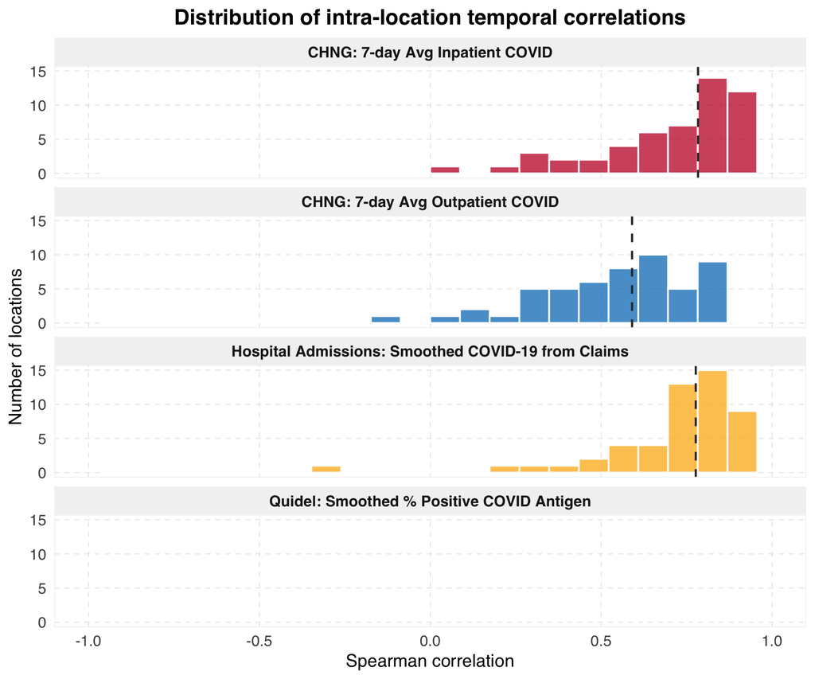

#### 2.2.1 Empirical Uncertainty

Intervals summarize empirical variation: spatial across dates, temporal across locations. Thick intervals are 25th-75th percentiles; thin intervals are 10th-90th percentiles.

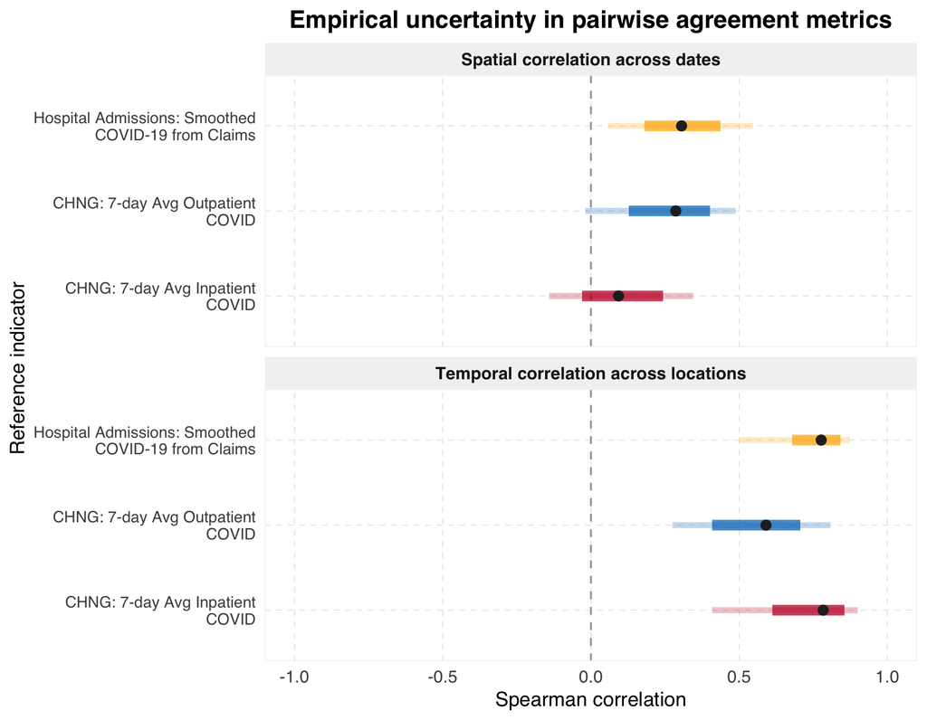

### 2.3 Lagged Correlations

Lag $\ell$ is measured in days. Positive lag compares earlier candidate values with current reference values; negative lag shifts the candidate later.

For lag $\ell$, the shifted candidate is compared with the reference:

$$C_{g,t-\ell}
\quad \text{vs.} \quad
R^{(k)}_{g,t}.$$

#### 2.3.1 Systematic Lag Analysis

Lag response curves show median within-location correlation by lag; ribbons show the 25th-75th percentile range. Matrix cells show mean correlation; white dots mark the lag with the highest mean temporal correlation for each reference.

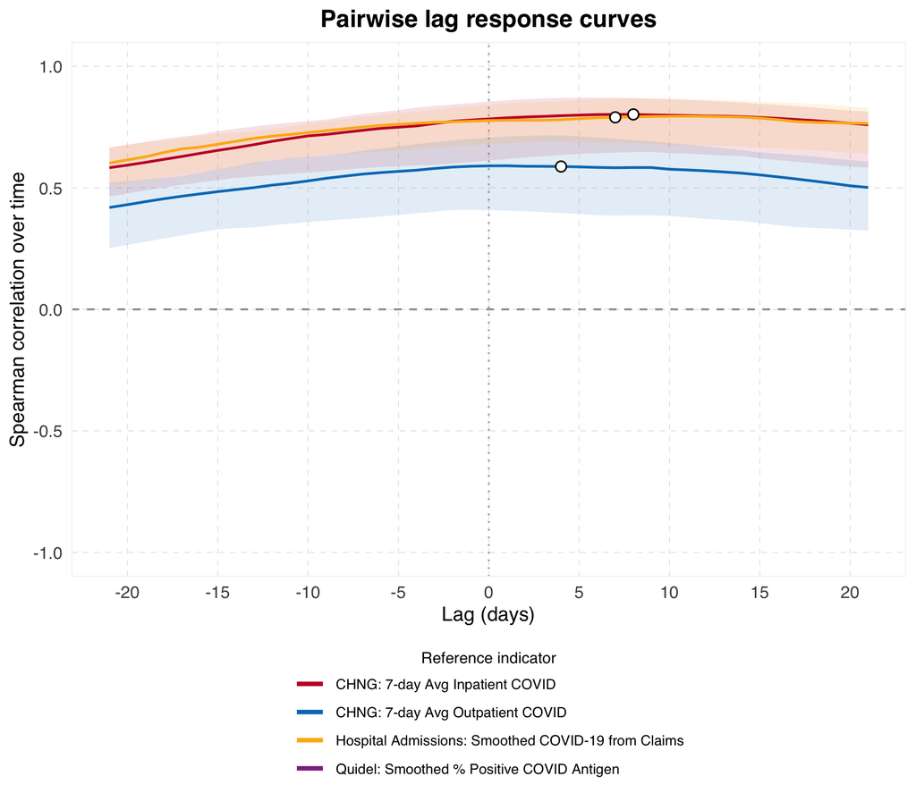

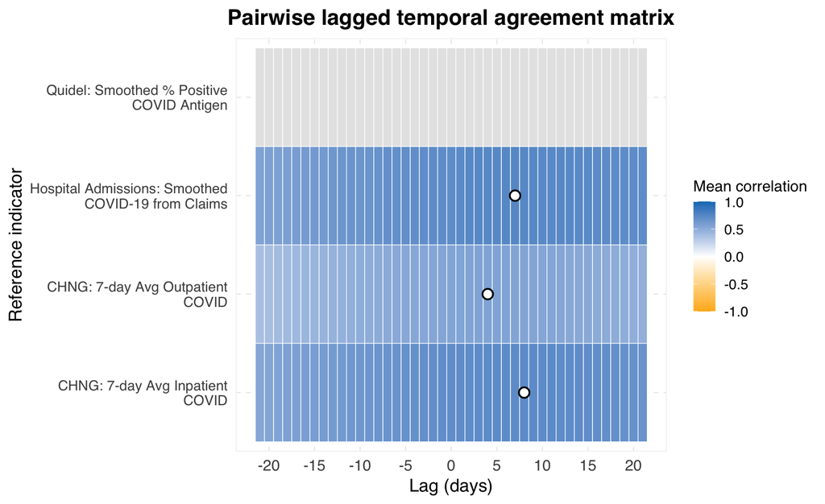

#### 2.3.2 Correlation over time, at different days

Correlations are computed across locations at each date after shifting the candidate. Each facet is one selected lag; color identifies reference.

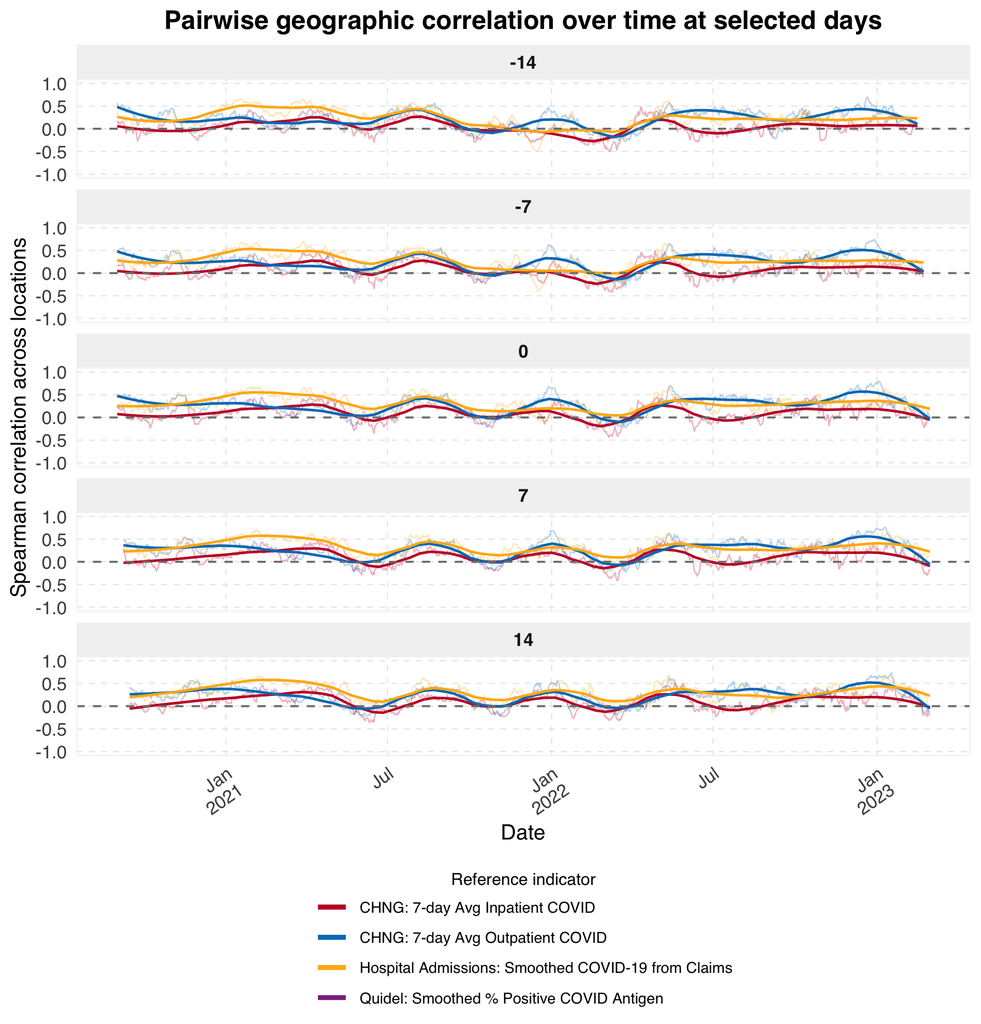

### 2.4 Geographic Heterogeneity at Optimal Lag

Maps and tables show location-level temporal agreement at the reference-specific optimal lag.

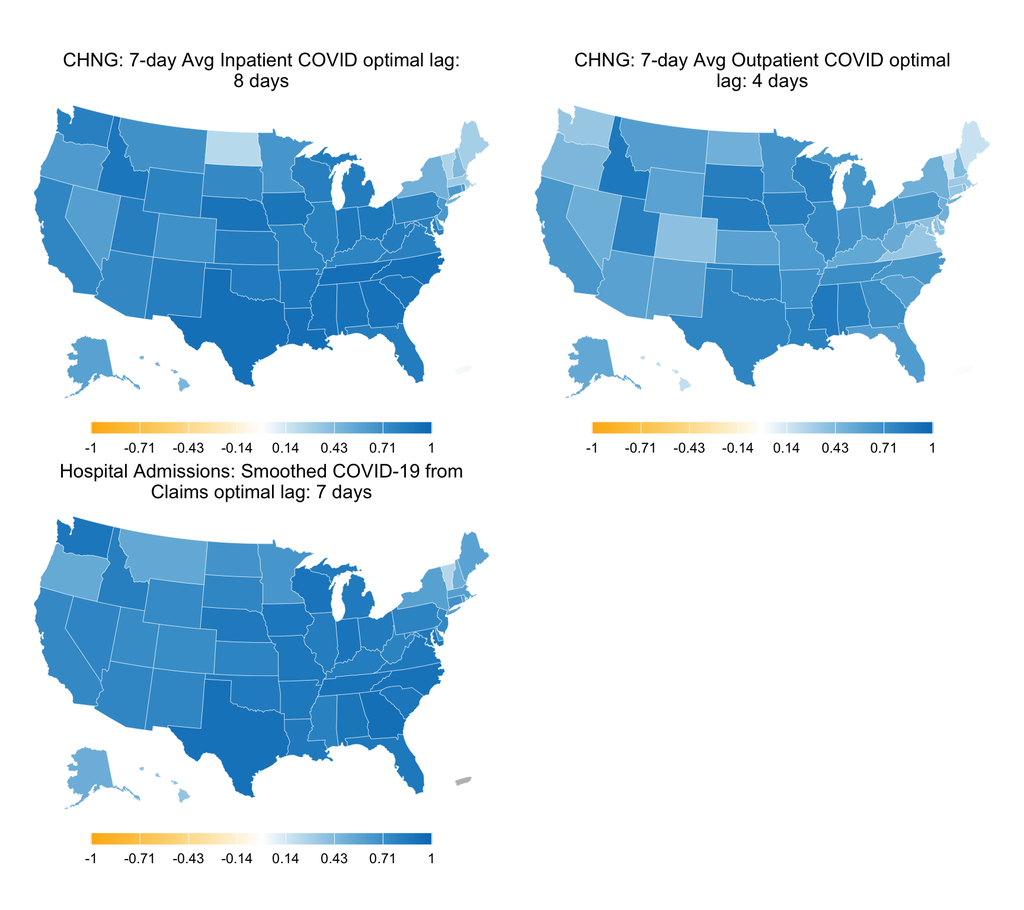

| Reference | Geo value | Geo name | Optimal lag | Spearman correlation | Rank |
| --- | --- | --- | --- | --- | --- |
| CHNG: 7-day Avg Inpatient COVID | tn | Tennessee | 8 | 0.9310716820668292 | 1 |
| CHNG: 7-day Avg Inpatient COVID | tx | Texas | 8 | 0.9307907619982156 | 2 |
| CHNG: 7-day Avg Inpatient COVID | la | Louisiana | 8 | 0.9251770931799114 | 3 |
| CHNG: 7-day Avg Inpatient COVID | nc | North Carolina | 8 | 0.9188138121564888 | 4 |
| CHNG: 7-day Avg Inpatient COVID | ga | Georgia | 8 | 0.9150563815947527 | 5 |
| CHNG: 7-day Avg Inpatient COVID | ms | Mississippi | 8 | 0.9131092823280695 | 6 |
| CHNG: 7-day Avg Inpatient COVID | al | Alabama | 8 | 0.9088015258384308 | 7 |
| CHNG: 7-day Avg Inpatient COVID | sc | South Carolina | 8 | 0.9009243983447847 | 8 |
| CHNG: 7-day Avg Inpatient COVID | ne | Nebraska | 8 | 0.8989088710032095 | 9 |
| CHNG: 7-day Avg Inpatient COVID | ia | Iowa | 8 | 0.8933146703894016 | 10 |

[output cut: 149 more lines]

#### 2.4.1 Locations With Minimum Temporal Agreement

Locations with minimum temporal correlation at each reference-specific optimal lag.

Locations with minimum temporal agreement for each candidate/reference pair at the reference-specific optimal lag.

| Reference | Geo value | Geo name | Optimal lag | Temporal Spearman correlation |
| --- | --- | --- | --- | --- |
| CHNG: 7-day Avg Inpatient COVID | pr | Puerto Rico Commonwealth | 8 | 0.037 |
| CHNG: 7-day Avg Inpatient COVID | nd | North Dakota | 8 | 0.234 |
| CHNG: 7-day Avg Inpatient COVID | vt | Vermont | 8 | 0.271 |
| CHNG: 7-day Avg Inpatient COVID | me | Maine | 8 | 0.296 |
| CHNG: 7-day Avg Inpatient COVID | ma | Massachusetts | 8 | 0.320 |
| CHNG: 7-day Avg Outpatient COVID | vi | U.S. Virgin Islands | 4 | -0.080 |
| CHNG: 7-day Avg Outpatient COVID | pr | Puerto Rico Commonwealth | 4 | 0.011 |
| CHNG: 7-day Avg Outpatient COVID | vt | Vermont | 4 | 0.148 |
| CHNG: 7-day Avg Outpatient COVID | me | Maine | 4 | 0.179 |
| CHNG: 7-day Avg Outpatient COVID | hi | Hawaii | 4 | 0.199 |
| Hospital Admissions: Smoothed COVID-19 from Claims | vt | Vermont | 7 | 0.243 |
| Hospital Admissions: Smoothed COVID-19 from Claims | hi | Hawaii | 7 | 0.358 |
| Hospital Admissions: Smoothed COVID-19 from Claims | dc | District of Columbia | 7 | 0.436 |
| Hospital Admissions: Smoothed COVID-19 from Claims | nh | New Hampshire | 7 | 0.506 |
| Hospital Admissions: Smoothed COVID-19 from Claims | ak | Alaska | 7 | 0.509 |

### 2.5 Reference Agreement Check

Context check: agreement among the selected reference indicators.

For references $j$ and $k$, date-specific spatial agreement is

$$s^{(j,k)}_{\text{ref},t}
= \operatorname{cor}_S
\left(
\{R^{(j)}_{g,t}\}_{g},
\{R^{(k)}_{g,t}\}_{g}
\right).$$

The heatmap shows the mean of $s^{(j,k)}_{\text{ref},t}$ across dates.

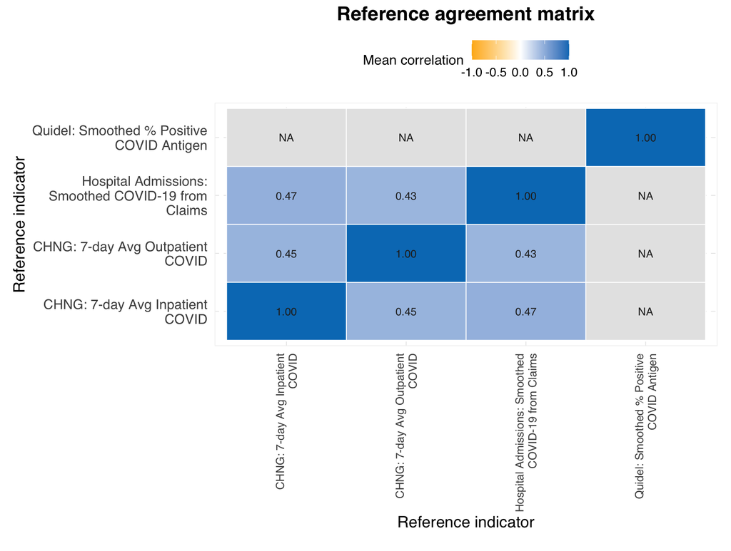

## 3 Summary

Main pairwise metrics. References are not combined.

Multi-reference pairwise metrics

| Reference | Mean geographic correlation | Median geographic correlation | Mean temporal correlation | Median temporal correlation | % locations \|correlation\| > 0.5 | Optimal lag | Mean correlation at optimal lag | Median correlation at optimal lag |
| --- | --- | --- | --- | --- | --- | --- | --- | --- |
| Hospital Admissions: Smoothed COVID-19 from Claims | 0.304 | 0.306 | 0.714 | 0.777 | 88% | 7 | 0.750 | 0.790 |
| CHNG: 7-day Avg Inpatient COVID | 0.098 | 0.093 | 0.702 | 0.783 | 83% | 8 | 0.721 | 0.802 |
| CHNG: 7-day Avg Outpatient COVID | 0.262 | 0.286 | 0.550 | 0.590 | 62% | 4 | 0.555 | 0.588 |
| Quidel: Smoothed % Positive COVID Antigen | No overlap | No overlap | No overlap | No overlap | No overlap | No overlap | No overlap | No overlap |